# Hands-on Training on Identifying Spatial Clusters of High and Low Acute Malnutrition

Leveraging geographical coordinates to locate areas with elevated acute malnutrition

### Check on Software Installations

- SaTScan version 3.10.5
- R version 4.6.0

### Why caring about spatial analysis in the work we do?

- Acute malnutrition may exhibit **spatial variability:**
  - Over a survey area, some places may exhibit higher rates than others, whereas others may exhibit lower rates.
  - This is acknowledged in the SMART Methodology as well as in the IPC.

#### In the SMART Methodology

Index of Dispersion

#### In the IPC Manual v3.0: When Design Effect is > 1.3

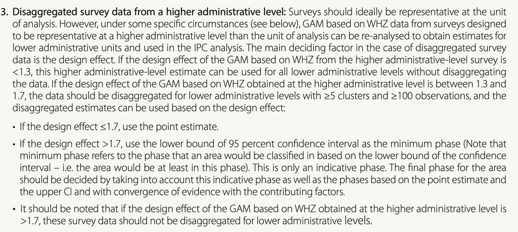

Lear more: [IPCinfo.org](https://www.ipcinfo.org/fileadmin/user_upload/ipcinfo/manual/IPC_Technical_Manual_3_Final.pdf)

# What are spatial clusters, and how are they detected?

> Clustering, in spatial epidemiology, refers to the detection of “unusual” aggregation of disease.

-Lawson (2006)

> Spatial epidemiology is often concerned with location, size, and intensity of the clusters when studying local clustering.

-Lawson et. al (2016)

### Spatial Scan Tests of Clusters

- Proposed by [Martin Kulldorf](https://en-wikipedia-org.translate.goog/wiki/Martin_Kulldorff?_x_tr_sl=en&_x_tr_tl=pt&_x_tr_hl=pt&_x_tr_pto=tc)

**How does it work?**

- The method imposes a large number of scanning windows of variable sizes onto the study area and compares the area inside against those outside the scanning windows.
- The procedure of finding the most-likely cluster is formulated using an hypothesis testing framework with a test statistisc based on the likelihood ratio test.

**Models based on type of variable**

There are several models, each depending on the type of variable that characterizes the phenomenon to be analysed.

- For acute malnutrition a Bernoulli model is used. It deals with dichotomous variables: **cases** and **non-cases**

[figure not shown]

# Introduction to SaTScan Software

Learn mode: [SaTScan Software](https://www.satscan.org)

# Introduction to wowi Software

[figure not shown]

Learn more: [wowi](https://tiwowi.github.io/wowi/)

### What is `wowi` ? 🧐

- `wowi` means *where* in *Elómwè*
- A lightweight, field-ready R-powered software built on top of SaTScan.
- Currently, it only suppports the scanning of spatial clusters of global acute malnutrition only.
- It depends on:
  - SaTScan for the actual spatial scan
  - `mwana` for wrangling of anthropometric data before piping into SaTScan analysis workflow.
- Users must have SaTScan installed on their computer; in spite of that, users will never have to open SaTScan - `wowi` communicates internally with SaTScan to run the analysis needless to manually.
- User will only have to open `wowi` app user iterfarce and give the instructions to SaTScan from there.

### Installing `wowi` library in R

- Install `remotes` library.
- Type/copy and paste the following command:

```r
install.packages("remotes")
```

- Then, install `wowi` with the following command:

```r
remotes::install_github(repo = "tiwowi/wowi", dependencies = TRUE)
```

- Once installed, launch the app running the following command:

```r
wowi::ww_run_app()
```

- The above code will open `wowi` app on your default web browser.

### Understanding data wrangling process in wowi

- `wowi` lets you scan for spatial clusters of global acute malnutrition defined on the basis of the following methods:

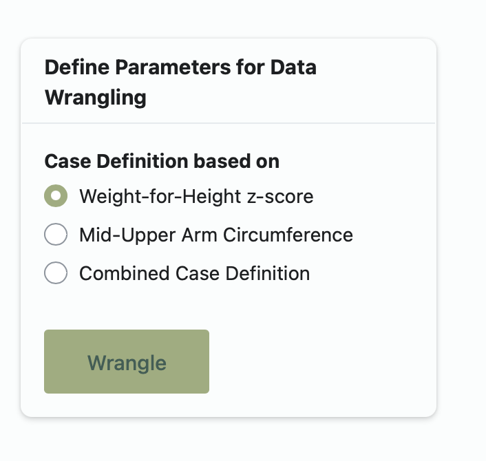

- **Weight-for-Height z-score** applies the SMART flagging criterion of +/-3 zscores of the survey mean.
- **Mid-Upper Arm Circumference**: it calculates z-scores of MUAC-for-Age, and then identifies outliers applying the same criterion of +/-3 z-scores of the survey mean.
- [**Combined Prevalence**](https://mphimo.github.io/mwana/reference/mw_estimate_prevalence_combined.html): It applyies flagging criterion on weight-for-height and on MUAC-for-Age zscores separately, then it removes flagged records in each.

Learn more: [mwana](https://mphimo.github.io/mwana/)